# Homework 06

## Question 1: Compare KNN and logistic regression

Use breast-cancer.csv, which contains 569 cases from the [Wisconsin Diagnostic Breast Cancer dataset](https://archive.ics.uci.edu/dataset/17/breast%2Bcancer%2Bwisconsin%2Bdiagnostic). Predict `y` (1 for malignant and 0 for benign) using `mean_radius`, `mean_texture`, and `mean_smoothness`.

Set a random seed and randomly split the observations into 70% training and 30% test data. Use the same split for every model. Standardize the predictors using the training means and standard deviations, and apply the same transformations to the test data.

Fit ordinary logistic regression with an intercept and no penalty, and KNN with Euclidean distance, equal neighbor weights, and

$$k\in\{5,15,25,35,45\}.$$

Using the estimated probabilities for `y = 1` on the test data, plot all six ROC curves in one figure and report their AUC values. Which of the six fitted models do you prefer? Give a brief justification based on your results.

**Answer 1.** I used the course-provided split in breast-cancer-split.csv, which records the random 70/30 split generated with seed `432` (398 training, 171 test). Python and R draw different samples from the same seed, so using the saved split keeps the split identical for every model and reproducible across languages. The three predictors were standardized with the training means and standard deviations, and the same transformation was applied to the test rows.

**Show the workflow**

```python
import numpy as np
import pandas as pd
import matplotlib.pyplot as plt
from sklearn.linear_model import LogisticRegression
from sklearn.neighbors import KNeighborsClassifier
from sklearn.metrics import roc_auc_score, roc_curve

bc = pd.read_csv("data/breast-cancer.csv")
split = pd.read_csv("data/breast-cancer-split.csv")
assert (split["row"].to_numpy() == np.arange(1, len(bc) + 1)).all()

predictors = ["mean_radius", "mean_texture", "mean_smoothness"]
X = bc[predictors].to_numpy()
y = bc["y"].to_numpy()
is_train = (split["split"] == "train").to_numpy()

X_train_raw, X_test_raw = X[is_train], X[~is_train]
y_train, y_test = y[is_train], y[~is_train]

# Standardize with training statistics only, then apply to both sets.
train_mean = X_train_raw.mean(axis=0)
train_sd = X_train_raw.std(axis=0, ddof=1)
X_train = (X_train_raw - train_mean) / train_sd
X_test = (X_test_raw - train_mean) / train_sd

print(f"training n = {len(y_train)}, test n = {len(y_test)}")
```

```
training n = 398, test n = 171
```

**Show the workflow**

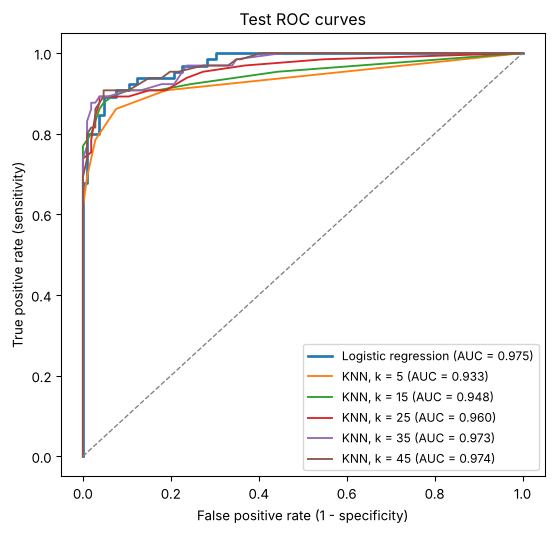

Test-set ROC curves for unpenalized logistic regression and KNN with k = 5, 15, 25, 35, 45.

|  | Model | Test AUC |
| --- | --- | --- |
| 0 | Logistic regression | 0.9746 |
| 1 | KNN, k = 5 | 0.9329 |
| 2 | KNN, k = 15 | 0.9480 |
| 3 | KNN, k = 25 | 0.9599 |
| 4 | KNN, k = 35 | 0.9727 |
| 5 | KNN, k = 45 | 0.9741 |

```python
q1_models = {"Logistic regression": LogisticRegression(penalty=None, max_iter=10000)}
for k in [5, 15, 25, 35, 45]:
    q1_models[f"KNN, k = {k}"] = KNeighborsClassifier(
        n_neighbors=k, weights="uniform", metric="euclidean"
    )

q1_rows = []
fig, ax = plt.subplots(figsize=(6.5, 6))
for name, model in q1_models.items():
    model.fit(X_train, y_train)
    p_test = model.predict_proba(X_test)[:, 1]  # estimated P(y = 1)
    fpr, tpr, _ = roc_curve(y_test, p_test)
    auc = roc_auc_score(y_test, p_test)
    q1_rows.append({"Model": name, "Test AUC": round(auc, 4)})
    ax.plot(fpr, tpr, lw=2 if name.startswith("Logistic") else 1.4,
            label=f"{name} (AUC = {auc:.3f})")

ax.plot([0, 1], [0, 1], ls="--", color="grey", lw=1)
ax.set_xlabel("False positive rate (1 - specificity)")
ax.set_ylabel("True positive rate (sensitivity)")
ax.set_title("Test ROC curves")
ax.legend(loc="lower right", fontsize=9)
plt.show()

pd.DataFrame(q1_rows)
```

| Model | Test AUC |
| --- | --- |
| Logistic regression | 0.9746 |
| KNN, $k=5$ | 0.9329 |
| KNN, $k=15$ | 0.9480 |
| KNN, $k=25$ | 0.9599 |
| KNN, $k=35$ | 0.9727 |
| KNN, $k=45$ | 0.9741 |

The fitted logistic model on the standardized scale has intercept $-1.171$ and slopes $5.329$ (radius), $1.788$ (texture), and $2.149$ (smoothness).

**Preferred model: logistic regression.** It has the highest test AUC (0.9746). KNN improves steadily as $k$ grows, because averaging over more neighbors reduces the variance of the estimated probabilities, but even at $k=45$ it only matches logistic regression (0.9741) and does not beat it. With three predictors and a decision boundary that looks close to linear in these features, the logistic model captures the signal with four parameters, gives smooth probabilities instead of the coarse multiples of $1/k$ that KNN produces, and is easier to interpret through its coefficients. The gap between logistic regression and KNN with $k\ge35$ is small enough that it could change with a different split, so the simplicity and interpretability of the logistic model are what tip the choice.

## Question 2: Training and test ROC curves

Use the same data, training/test split, and standardization as in Question 1. Fit KNN with Euclidean distance, equal neighbor weights, and

$$k\in\{1,3,5,10,20\}.$$

Use each fitted model to estimate probabilities for both the training and test observations. For training predictions, include each observation itself among its $k$ nearest neighbors.

For each $k$, use a separate panel to show the training and test ROC curves together. Report both AUC values.

Explain the difference between training and test performance and how it changes with $k$. In particular, explain what happens at $k=1$ and why training performance may not reflect performance on new observations.

**Answer 2.** I reused the split and standardized predictors from Question 1. For training predictions, `predict_proba` on the training rows searches the full training set, so each observation is its own nearest neighbor (distance 0), as the question requires.

**Show the workflow**

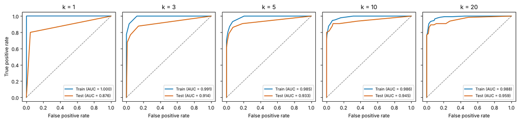

Training and test ROC curves for KNN with k = 1, 3, 5, 10, 20.

|  | k | Training AUC | Test AUC |
| --- | --- | --- | --- |
| 0 | 1 | 1.0000 | 0.8764 |
| 1 | 3 | 0.9905 | 0.9138 |
| 2 | 5 | 0.9847 | 0.9329 |
| 3 | 10 | 0.9862 | 0.9446 |
| 4 | 20 | 0.9880 | 0.9586 |

```python
q2_k = [1, 3, 5, 10, 20]
q2_rows = []
fig, axes = plt.subplots(1, len(q2_k), figsize=(15, 3.6), sharex=True, sharey=True)
for ax, k in zip(axes, q2_k):
    knn = KNeighborsClassifier(n_neighbors=k, weights="uniform", metric="euclidean")
    knn.fit(X_train, y_train)
    p_train = knn.predict_proba(X_train)[:, 1]  # each point counts itself
    p_test = knn.predict_proba(X_test)[:, 1]
    auc_train = roc_auc_score(y_train, p_train)
    auc_test = roc_auc_score(y_test, p_test)
    q2_rows.append({"k": k, "Training AUC": round(auc_train, 4),
                    "Test AUC": round(auc_test, 4)})
    for p, yy, lab, col in [(p_train, y_train, "Train", "#0072B2"),
                            (p_test, y_test, "Test", "#D55E00")]:
        fpr, tpr, _ = roc_curve(yy, p)
        ax.plot(fpr, tpr, color=col, lw=1.6,
                label=f"{lab} (AUC = {roc_auc_score(yy, p):.3f})")
    ax.plot([0, 1], [0, 1], ls="--", color="grey", lw=1)
    ax.set_title(f"k = {k}")
    ax.set_xlabel("False positive rate")
    ax.legend(loc="lower right", fontsize=8)
axes[0].set_ylabel("True positive rate")
plt.tight_layout()
plt.show()

pd.DataFrame(q2_rows)
```

| $k$ | Training AUC | Test AUC | Gap |
| --- | --- | --- | --- |
| 1 | 1.0000 | 0.8764 | 0.1236 |
| 3 | 0.9905 | 0.9138 | 0.0767 |
| 5 | 0.9847 | 0.9329 | 0.0518 |
| 10 | 0.9862 | 0.9446 | 0.0416 |
| 20 | 0.9880 | 0.9586 | 0.0294 |

**Training versus test.** Training AUC is above test AUC for every $k$, because each training point is part of its own neighborhood and therefore pulls its estimated probability toward its own label. That self-vote is worth $1/k$ of the prediction, so the optimism is largest for small $k$ and shrinks as $k$ grows. Test AUC moves the other way, rising from 0.876 at $k=1$ to 0.959 at $k=20$, since larger neighborhoods average away more noise. The training-test gap falls from 0.124 to 0.029 as $k$ goes from 1 to 20. Training AUC does not decrease monotonically (it dips at $k=5$ and recovers slightly), but it stays near 0.99 throughout and does not track the much larger changes in test performance. Larger $k$ is not always better: once neighborhoods get too wide, averaging over distant observations smooths away local structure, so test AUC would eventually level off or fall.

**What happens at $k=1$.** With $k=1$ and no duplicated training rows, every training observation’s only neighbor is itself, so its estimated probability is exactly its own label (0 or 1). The classifier reproduces the training labels perfectly and the training ROC curve goes straight up to $(0,1)$, giving AUC $=1$. This says nothing about generalization: the model has memorized the training data, including its noise. On new observations the nearest training point is a different case, its label is a single noisy vote, and the predicted probabilities are only 0 or 1, so the test ROC curve has a single interior corner, its AUC equals $(\text{sensitivity}+\text{specificity})/2$ at that point, and it drops to 0.876, the worst of all five models.

Training performance for KNN is therefore not a reliable guide to performance on new data, since it rewards the model for using the answer it is being graded on. Choosing $k$ should be based on held-out test data or cross-validation, where larger $k$ (here, $k=20$) clearly does better.

## Question 3: Peer evaluation of Homework 5

You will receive two Homework 5 submissions to review. The instructor’s GitHub account, **rqzhu-aide**, will open a **GitHub Issue** in the repository containing your Homework 5 submission. It will contain links to two other students’ repositories, where you can find their submitted homework reports.

Open your repository’s **Issues** tab on GitHub to find the assignment. You may ask AI to explain GitHub Issues or help you locate the assignment.

Choose **one specific mistake or item for improvement** from any question in either report.

1. **Identify the mistake or item for improvement.** State which report and question you selected, and briefly describe what is wrong or could be improved. Examples include incorrect code, a calculation error, a misinterpretation of results, a plot that could communicate the findings more clearly, or anything else you think could be done better.

I selected HiImChuang’s Homework 5 report, Question 3(c). The answer explains why KNN does better with m = 3 than m = 30, but it only answers half of the second part. It says what n is, but never explains why the observed data are not confined exactly to an m-dimensional linear space.

2. **Explain your assessment.** Quote the relevant text, code, or figure caption exactly. Explain why the selected answer is incorrect or how it could be improved, referring to its reasoning, calculations, code, figures, or interpretation. **Complete this part yourself, without AI assistance.**

The report says: “Eta plays the role of random noise in the generation of the observed covariates X. Or it can also be viewed as the measurement error in the observed variables.” The question asks two things here: what role n plays, and why the observed data are not confined exactly to an m-dimensional linear space. The quoted text only names n as noise or measurement error. It doesn’t explain how η affects KNN, and it doesn’t answer the second part at all. Without noise, every observation is a combination of the m columns of A, so all the data sit in the column space of A, which has dimension at most m. Adding n, independent noise in all 100 coordinates, pushes each point off that subspace in every direction That matters for KNN because distances are computed in all 100 coordinates.

3. **Provide a correction.** Write a corrected or improved answer to the selected question, including any calculations, code, or figures needed.

When m = 3, the 100 observed covariates are driven by only three latent variables, and two of them determine the mean of Y, so Euclidean distance in X mostly reflects variation that is relevant to the response. When m = 30, distance also responds to 28 latent variables that don’t enter Y. Two observations can be close on Z1 and Z2 but far apart on the other 28 directions, so with only 200 training points the nearest neighbors in X are less informative about Y. This is why the m = 30 curve has higher test MSE at every k. Since each entry of A has variance 4/3, the signal contributes about 100·m·(4/3) to the total variance and the noise contributes 100. For m = 3, about 80% of the variation lies in the 3 signal directions and the other 20% is spread over the remaining 97.

After completing your review, **open a GitHub Issue in the repository containing the report you selected**. Identify the report and question, and include your assessment and a detailed revision plan explaining what the author should change and why. Include a link to your posted GitHub Issue in your Homework 6 answer.

https://github.com/HiImChuang/stat432-fall2026/issues/2